# Game Sales Data Report

Ian Carlson, Dennis De Armas, Berlin Nieves

Data 2401

# Introduction

When a video game is created, one important question remains in the minds of its developers: “Will this game be successful?” The success of a video game can have a big impact on a company’s reputation, popularity, and financial growth. With so many games being released each year, understanding why certain games are more successful than others is important for developers, publishers, and the gaming industry. By looking at different factors that may contribute to a game’s success, we can get a better understanding of what affects its performance in the market.

The purpose of our report is to explore the relationship between video game characteristics and their commercial success. To do this, we will analyze a dataset containing video games released through 2016, including information such as global sales, regional sales, critic scores, user ratings, and release years. We will use exploratory data analysis, scatterplots, and correlation analysis to look for patterns and relationships between these variables. These methods will help us see whether games with higher review scores tend to have greater sales and if sales trends are similar across different regions.

Through our analysis, we hope to identify which factors have the strongest relationships with video game sales and get a better understanding of what contributes to commercial success. Our findings may help developers and publishers make better decisions about future games, while also giving readers a better idea of how consumer opinions, critic reviews, and sales performance are connected.

# Problem Statement and Questions

- What factors influence the success of a video game?
  - Which game genres were the most commercially successful globally?
  - What regions do the top genres sell the best in?
  - Do video games with higher critic scores sell more copies worldwide?
  - Do newer video games receive higher or lower user ratings?

# Packages

```r
# The tidyverse library is used for our exploratory analysis and plotting. With this we can use tools like dplyer and ggplot.
library(tidyverse)

# The plotly library is used for making our graphs interactive, that way they can be even more informative than that of a static graph.
library(plotly)
```

# Data Preparation

Kaggle Dataset: SID_TWR. (2019, May 10). Video games sales dataset. Kaggledatasets. https://www.kaggle.com/datasets/sidtwr/videogames-sales-dataset

Source of data: Video game charts, game sales, top sellers, game data - VGChartz. (n.d.). Www.Vgchartz.Com. Retrieved November 6, 2026, from https://www.vgchartz.com/

VGChartz Staff: https://www.vgchartz.com/staff.php

This kaggle data set was originally from Gregory Smith’s web scrape of VGChartz’s Video Game Sales, but kaggle creator SID_TWR extended it with more variables from a web scrape of Metacritic. The VGChartz data come from the VGChartz team, with CEO Brett Walton; linked above is the homepage and staff page of VGChartz. The VGChartz staff pages states that, “Brett Walton created VGChartz in the summer of 2006 as a way of collating all publicly available videogame sales data into one place” (VGChartz). Kaggle creator SID_TWR states that he was motivated by Gregory Smith’s web scrape to extend the data in order to be more informative. The data was last updated in 2019 but the data itself has records up to 2016. One peculiarity of the data is that there is a notable amount of missing data when it comes to ratings. As SID_TWR states, “Metacritic only covers a subset of the platforms” (SID_TWR).

Let’s start by reading the data from the csv.

```r
# Reading data from csv file using read.csv()
game_data <- read.csv("Game_Sales.csv")
```

Next, there are two games that are who’s names are blank and missing important data. Most likely, only some of the data was available and whoever collected it decided to add what they could. Since they are missing key identifiers, let’s remove them.

```r
game_data |> filter(Name == "") # Missing data in question
```

```
##   Name Platform Year_of_Release Genre             Publisher NA_Sales EU_Sales
## 1           GEN            1993       Acclaim Entertainment     1.78     0.53
## 2           GEN            1993       Acclaim Entertainment     0.00     0.00
##   JP_Sales Other_Sales Global_Sales Critic_Score Critic_Count User_Score
## 1     0.00        0.08         2.39           NA           NA         NA
## 2     0.03        0.00         0.03           NA           NA         NA
##   User_Count Developer Rating
## 1         NA
## 2         NA
```

```r
game_data <- game_data |> filter(Name != "") # Removing these two entries
```

Since each region has a column for sales, this data is not tidy. However, depending on the type of analysis we intend to do, this format could still be useful. In order to fix this, let’s make a tidier version of the data. This way, we can choose between the two data sets depending on the question we are asking.

```r
game_data_tidy <- game_data |>
  rename('North America' = NA_Sales,
         'European Union' = EU_Sales,
         'Japan' = JP_Sales,
         'Other' = Other_Sales,
         'Global' = Global_Sales) |>
  pivot_longer(cols = c('North America', 'European Union', 'Japan', 'Other', 'Global'),
                          names_to = "Region",
                          values_to = "Sales") |>
  relocate(Region, .before = Platform) |>
  relocate(Sales, .before = Critic_Score)
```

Let’s take a look at our cleaned data.

```r
# Taking a "glimpse" of the data
glimpse(game_data_tidy)
```

```
## Rows: 83,585
## Columns: 13
## $ Name            <chr> "Wii Sports", "Wii Sports", "Wii Sports", "Wii Sports"…
## $ Region          <chr> "North America", "European Union", "Japan", "Other", "…
## $ Platform        <chr> "Wii", "Wii", "Wii", "Wii", "Wii", "NES", "NES", "NES"…
## $ Year_of_Release <chr> "2006", "2006", "2006", "2006", "2006", "1985", "1985"…
## $ Genre           <chr> "Sports", "Sports", "Sports", "Sports", "Sports", "Pla…
## $ Publisher       <chr> "Nintendo", "Nintendo", "Nintendo", "Nintendo", "Ninte…
## $ Sales           <dbl> 41.36, 28.96, 3.77, 8.45, 82.53, 29.08, 3.58, 6.81, 0.…
## $ Critic_Score    <int> 76, 76, 76, 76, 76, NA, NA, NA, NA, NA, 82, 82, 82, 82…
## $ Critic_Count    <int> 51, 51, 51, 51, 51, NA, NA, NA, NA, NA, 73, 73, 73, 73…
## $ User_Score      <dbl> 8.0, 8.0, 8.0, 8.0, 8.0, NA, NA, NA, NA, NA, 8.3, 8.3,…
## $ User_Count      <int> 322, 322, 322, 322, 322, NA, NA, NA, NA, NA, 709, 709,…
## $ Developer       <chr> "Nintendo", "Nintendo", "Nintendo", "Nintendo", "Ninte…
## $ Rating          <chr> "E", "E", "E", "E", "E", "", "", "", "", "", "E", "E",…
```

One thing we need to look out for once we start working with the data is any missing values that might affect our calculations.

In order to answer our questions, here are some important variables we are going to take a look at:

| Variable | Explanation |
| --- | --- |
| Name | This will be important to reference if we want to look at individual games. |
| Genre | We can use this variable to see what genres perform the best. |
| Region | We can use this variable to compare data between different regions |
| Sales | This is how we will determine if a game was **commercial** success. |
| Platform | We can use this variable to see what platforms have the most success. |

# Exploratory Data Analysis

## Which game genres were the most commercially successful globally?

The first question our report would like to explore is what game genres are the most commercially successful? In order to answer this question let’s take a look at a plot of Total Global Sales per Genre.

```r
genre_sales_plot <- game_data |> # Store Data to variable to use in plotly
  group_by(Genre) |> # Group Data by Genre
  summarize(total_global_sales = sum(Global_Sales, na.rm = T)) |> # Find the Total Global Sales for each Genre
  ggplot(aes(y = reorder(Genre, total_global_sales), # Create a plot of the findings
             x = total_global_sales,
             text = paste("Total Global Sales (Million):", total_global_sales))) + # "text" displays the exact number of units sold in ggplotly
  geom_col() + # Use a column chart since we have one discrete variable and one continuous variable
  labs(title = "Total Global Sales by Genre",
       x = "Total Global Sales (Million Units Sold)",
       y = "Genre") # Put genre on the y-axis for readability

ggplotly(genre_sales_plot, tooltip = "text") # ggplotly makes the graph interactive, use the "text" we made before as the tooltip
```

[interactive chart not shown]

Based on this graph, it’s clear that the `Action` genre of video game sells the best, with the `Sports` and `Shooter` genres coming in second and third respectively.

## What regions do the top genres sell the best in?

```r
genre_region_plot <- game_data |>
  group_by(Genre) |> # Grouping data by genre to calculate sales percentage for each
  mutate('NA' = (sum(NA_Sales) / sum(Global_Sales)) * 100, # Creating a column for the sales percentage for each region
         EU = (sum(EU_Sales) / sum(Global_Sales)) * 100,
         JP = (sum(JP_Sales) / sum(Global_Sales)) * 100,
         Other = (sum(Other_Sales) / sum(Global_Sales)) * 100) |>
  filter(Genre %in% c("Action", "Sports", "Shooter", "Role-Playing")) |> # Filtering to the top 5 genres we found previously
  select(Genre, 'NA', EU, JP, Other) |> # Selecting only the necessary columns
  pivot_longer(cols = c('NA', EU, JP, Other), # Cleaning the data to make it tidy for our purpose
               names_to = "Region",
               values_to = "Percentage") |>
  ggplot(aes(x = Genre,
             y = Percentage,
             fill = Region,
             text = paste0("Genre: ", Genre,
                          "<br>Percentage: ", Percentage, "%",
                          "<br>Region: ", Region))) +
  geom_col(position = "dodge") + # Using a dodged bar chart to make it easy to see which region a genre sells the best
  labs(title = "Genre Sales Percentage by Region") + theme_bw()

ggplotly(genre_region_plot, tooltip = "text")
```

[interactive chart not shown]

## Do newer video games receive higher or lower user ratings?

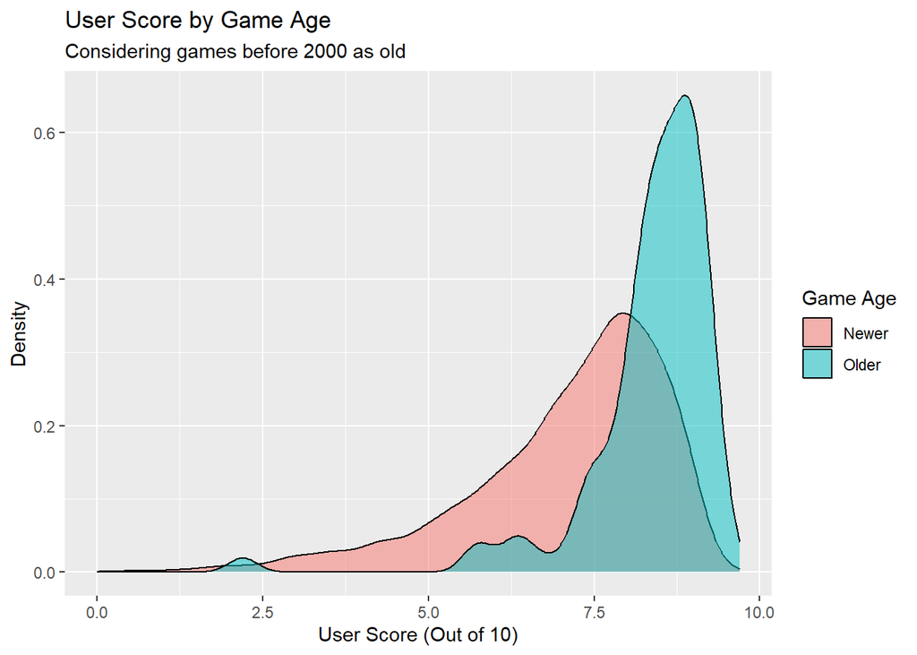

```r
game_data |>
  mutate(Game_Age = case_when(Year_of_Release < 2000 ~ "Older", Year_of_Release >= 2000 ~ "Newer")) |>
  filter(!is.na(User_Score)) |>
  ggplot(aes(x = User_Score, fill = Game_Age)) +
  geom_density(alpha = .5) +
  labs(title = "User Score by Game Age",
       x = "User Score (Out of 10)",
       y = "Density",
       subtitle = "Considering games before 2000 as old",
       fill = "Game Age")
```

## Do video games with higher critic scores sell more copies worldwide?

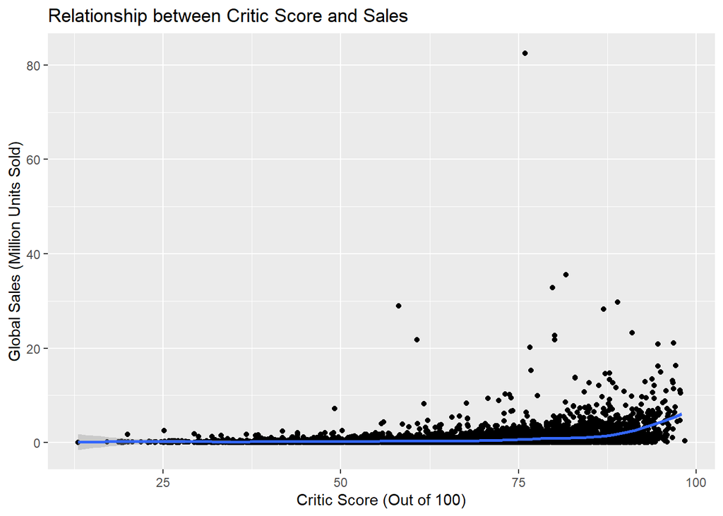

```r
game_data |>
  filter(!is.na(Critic_Score)) |>
  ggplot(aes(x = Critic_Score, y = Global_Sales)) +
  geom_jitter() +
  geom_smooth() +
  labs(title = "Relationship between Critic Score and Sales",
       x = "Critic Score (Out of 100)",
       y = "Global Sales (Million Units Sold)")
```

## What game publishers sell the most games

```r
game_data_tidy |>
  group_by(Publisher) |>
  summarize(Total_Sales = sum(Sales, na.rm = T)) |>
  slice_max(Total_Sales, n = 5)
```

```
## # A tibble: 5 × 2
##   Publisher                   Total_Sales
##   <chr>                             <dbl>
## 1 Nintendo                          3578.
## 2 Electronic Arts                   2234.
## 3 Activision                        1462.
## 4 Sony Computer Entertainment       1213.
## 5 Ubisoft                            943.
```

## What is the top selling game

```r
game_data_tidy |>
  filter(Region == "Global") |>
  slice_max(Sales, n = 1) |>
  select(Name, Platform, Publisher, Sales)
```

```
## # A tibble: 1 × 4
##   Name       Platform Publisher Sales
##   <chr>      <chr>    <chr>     <dbl>
## 1 Wii Sports Wii      Nintendo   82.5
```